# Explore_bikeshare_data

### Explore Bike Share Data

For this project, your goal is to ask and answer three questions about the available bikeshare data from Washington, Chicago, and New York. This notebook can be submitted directly through the workspace when you are confident in your results.

You will be graded against the project [Rubric](https://review.udacity.com/#!/rubrics/2508/view) by a mentor after you have submitted. To get you started, you can use the template below, but feel free to be creative in your solutions!

```r
ny = read.csv('new_york_city.csv')
wash = read.csv('washington.csv')
chi = read.csv('chicago.csv')
```

```r
head(ny)
```

| X | Start.Time | End.Time | Trip.Duration | Start.Station | End.Station | User.Type | Gender | Birth.Year |
| --- | --- | --- | --- | --- | --- | --- | --- | --- |
| 5688089 | 2017-06-11 14:55:05 | 2017-06-11 15:08:21 | 795 | Suffolk St & Stanton St | W Broadway & Spring St | Subscriber | Male | 1998 |
| 4096714 | 2017-05-11 15:30:11 | 2017-05-11 15:41:43 | 692 | Lexington Ave & E 63 St | 1 Ave & E 78 St | Subscriber | Male | 1981 |
| 2173887 | 2017-03-29 13:26:26 | 2017-03-29 13:48:31 | 1325 | 1 Pl & Clinton St | Henry St & Degraw St | Subscriber | Male | 1987 |
| 3945638 | 2017-05-08 19:47:18 | 2017-05-08 19:59:01 | 703 | Barrow St & Hudson St | W 20 St & 8 Ave | Subscriber | Female | 1986 |
| 6208972 | 2017-06-21 07:49:16 | 2017-06-21 07:54:46 | 329 | 1 Ave & E 44 St | E 53 St & 3 Ave | Subscriber | Male | 1992 |
| 1285652 | 2017-02-22 18:55:24 | 2017-02-22 19:12:03 | 998 | State St & Smith St | Bond St & Fulton St | Subscriber | Male | 1986 |

```r
head(wash)
```

| X | Start.Time | End.Time | Trip.Duration | Start.Station | End.Station | User.Type |
| --- | --- | --- | --- | --- | --- | --- |
| 1621326 | 2017-06-21 08:36:34 | 2017-06-21 08:44:43 | 489.066 | 14th & Belmont St NW | 15th & K St NW | Subscriber |
| 482740 | 2017-03-11 10:40:00 | 2017-03-11 10:46:00 | 402.549 | Yuma St & Tenley Circle NW | Connecticut Ave & Yuma St NW | Subscriber |
| 1330037 | 2017-05-30 01:02:59 | 2017-05-30 01:13:37 | 637.251 | 17th St & Massachusetts Ave NW | 5th & K St NW | Subscriber |
| 665458 | 2017-04-02 07:48:35 | 2017-04-02 08:19:03 | 1827.341 | Constitution Ave & 2nd St NW/DOL | M St & Pennsylvania Ave NW | Customer |
| 1481135 | 2017-06-10 08:36:28 | 2017-06-10 09:02:17 | 1549.427 | Henry Bacon Dr & Lincoln Memorial Circle NW | Maine Ave & 7th St SW | Subscriber |
| 1148202 | 2017-05-14 07:18:18 | 2017-05-14 07:24:56 | 398.000 | 1st & K St SE | Eastern Market Metro / Pennsylvania Ave & 7th St SE | Subscriber |

```r
head(chi)
```

| X | Start.Time | End.Time | Trip.Duration | Start.Station | End.Station | User.Type | Gender | Birth.Year |
| --- | --- | --- | --- | --- | --- | --- | --- | --- |
| 1423854 | 2017-06-23 15:09:32 | 2017-06-23 15:14:53 | 321 | Wood St & Hubbard St | Damen Ave & Chicago Ave | Subscriber | Male | 1992 |
| 955915 | 2017-05-25 18:19:03 | 2017-05-25 18:45:53 | 1610 | Theater on the Lake | Sheffield Ave & Waveland Ave | Subscriber | Female | 1992 |
| 9031 | 2017-01-04 08:27:49 | 2017-01-04 08:34:45 | 416 | May St & Taylor St | Wood St & Taylor St | Subscriber | Male | 1981 |
| 304487 | 2017-03-06 13:49:38 | 2017-03-06 13:55:28 | 350 | Christiana Ave & Lawrence Ave | St. Louis Ave & Balmoral Ave | Subscriber | Male | 1986 |
| 45207 | 2017-01-17 14:53:07 | 2017-01-17 15:02:01 | 534 | Clark St & Randolph St | Desplaines St & Jackson Blvd | Subscriber | Male | 1975 |
| 1473887 | 2017-06-26 09:01:20 | 2017-06-26 09:11:06 | 586 | Clinton St & Washington Blvd | Canal St & Taylor St | Subscriber | Male | 1990 |

# Question 1

What hour of the day has the highest number of bike trips?

```r
# Function to add an hour column (0–23) based on Start.Time
add_hour_column <- function(df) {
  st <- trimws(as.character(df$Start.Time))
  dt <- as.POSIXct(st, format = "%Y-%m-%d %H:%M:%S")
  df$hour <- as.numeric(format(dt, "%H"))
  df
}
```

```r
# Add hour column to each city dataset
ny   <- add_hour_column(ny)
chi  <- add_hour_column(chi)
wash <- add_hour_column(wash)
```

```r
# Count trips by hour and shows results (NA hours are excluded)
ny_hour_counts   <- table(ny$hour)
chi_hour_counts  <- table(chi$hour)
wash_hour_counts <- table(wash$hour)

ny_hour_counts
chi_hour_counts
wash_hour_counts
```

```
   0    1    2    3    4    5    6    7    8    9   10   11   12   13   14   15
 436  231  152   60   84  312 1212 2512 4337 3521 2471 2643 2866 3054 3157 3356
  16   17   18   19   20   21   22   23
3894 5503 5281 3594 2437 1646 1214  797
```

```
   0    1    2    3    4    5    6    7    8    9   10   11   12   13   14   15
  55   26   18   16   17   67  243  560  693  385  320  467  482  530  466  599
  16   17   18   19   20   21   22   23
 804 1039  679  435  268  237  146   78
```

```
   0    1    2    3    4    5    6    7    8    9   10   11   12   13   14   15
 227 3500 3421 3655 4541 6741 6994 8490 9805 5957 4788 5057 5569 1906 1774 2136
  16   17   18   19   20   21   22   23
2746 3958 3028 1772 1181  855  605  344
```

```r
# Identify the hour of day with the highest number of trips for each city and shows results
ny_peak_hour   <- as.numeric(names(which.max(ny_hour_counts)))
chi_peak_hour  <- as.numeric(names(which.max(chi_hour_counts)))
wash_peak_hour <- as.numeric(names(which.max(wash_hour_counts)))

ny_peak_hour
chi_peak_hour
wash_peak_hour
```

17

17

8

```r
# Number of trips that occurred during the peak hour for each city, showing max for each city
ny_peak_count   <- max(ny_hour_counts)
chi_peak_count  <- max(chi_hour_counts)
wash_peak_count <- max(wash_hour_counts)

ny_peak_count
chi_peak_count
wash_peak_count
```

5503

1039

9805

```r
# Convert hour count tables into data frames for plotting
ny_plot_df <- data.frame(hour = as.numeric(names(ny_hour_counts)),
                         trips = as.numeric(ny_hour_counts))

chi_plot_df <- data.frame(hour = as.numeric(names(chi_hour_counts)),
                          trips = as.numeric(chi_hour_counts))

wash_plot_df <- data.frame(hour = as.numeric(names(wash_hour_counts)),
                           trips = as.numeric(wash_hour_counts))
```

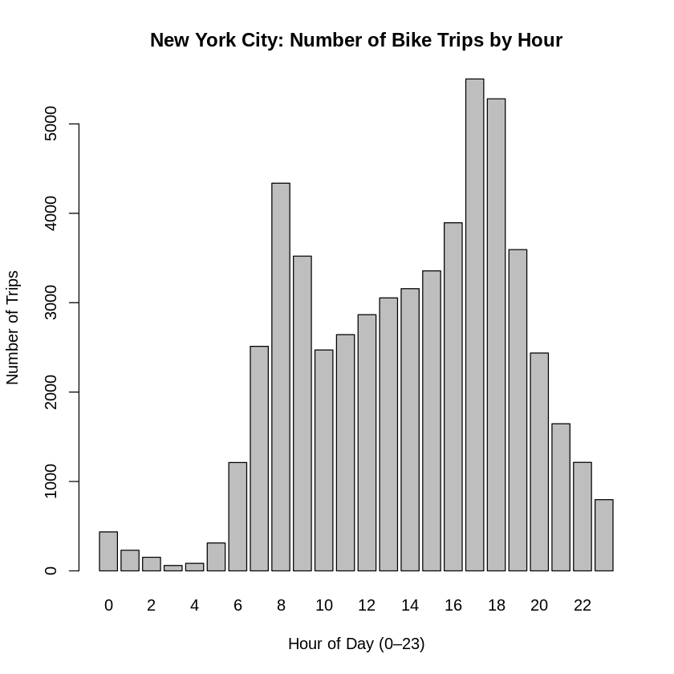

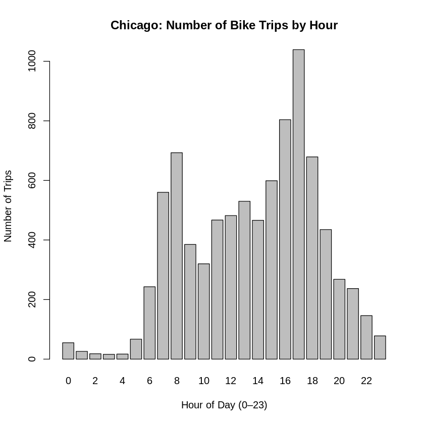

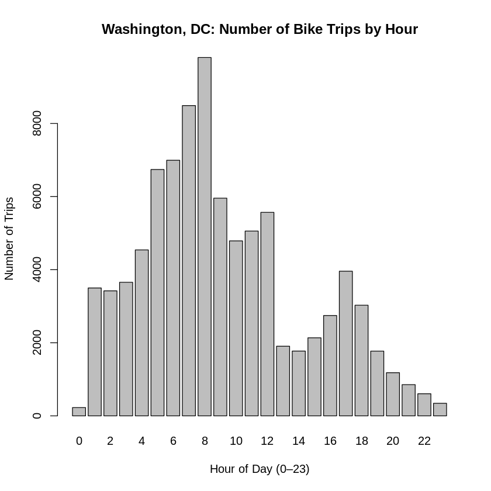

```r
# Plot: Trips by hour for New York City
barplot(ny_plot_df$trips,
        names.arg = ny_plot_df$hour,
        main = "New York City: Number of Bike Trips by Hour",
        xlab = "Hour of Day (0–23)",
        ylab = "Number of Trips")

# Plot: Trips by hour for Chicago
barplot(chi_plot_df$trips,
        names.arg = chi_plot_df$hour,
        main = "Chicago: Number of Bike Trips by Hour",
        xlab = "Hour of Day (0–23)",
        ylab = "Number of Trips")

# Plot: Trips by hour for Washington, DC
barplot(wash_plot_df$trips,
        names.arg = wash_plot_df$hour,
        main = "Washington, DC: Number of Bike Trips by Hour",
        xlab = "Hour of Day (0–23)",
        ylab = "Number of Trips")
```

**Summary of your question 1 results goes here.** The hour with the highest number of bike trips differs by city. In both New York City and Chicago, the greatest number of trips occurs at 5 PM (17:00), which aligns with evening commuting patterns. In contrast, Washington, DC experiences its highest bike usage at 8 AM, indicating a stronger morning commute trend. One Washington record contained an invalid start time and was excluded from the hour-based analysis.

### Question 2

What are the most commonly used start stations in each city?

```r
# Count trips by start station for each city
ny_station_counts   <- sort(table(ny$Start.Station), decreasing = TRUE)
chi_station_counts  <- sort(table(chi$Start.Station), decreasing = TRUE)
wash_station_counts <- sort(table(wash$Start.Station), decreasing = TRUE)
```

```r
# Select the top 5 most common start stations and show results
ny_top5_stations   <- head(ny_station_counts, 5)
chi_top5_stations  <- head(chi_station_counts, 5)
wash_top5_stations <- head(wash_station_counts, 5)

ny_top5_stations
chi_top5_stations
wash_top5_stations
```

```
Pershing Square North       W 21 St & 6 Ave    Broadway & E 22 St
                  592                   385                   383
   E 17 St & Broadway West St & Chambers St
                  380                   364
```

```
     Streeter Dr & Grand Ave    Lake Shore Dr & Monroe St
                         210                          140
Clinton St & Washington Blvd      Clinton St & Madison St
                         120                          102
         Canal St & Adams St
                         101
```

```
     Columbus Circle / Union Station                     Lincoln Memorial
                                1700                                 1546
           Jefferson Dr & 14th St SW Massachusetts Ave & Dupont Circle NW
                                1488                                 1219
                  Jefferson Memorial
                                1068
```

```r
# Convert top 5 station counts to data frames for plotting

ny_station_df <- data.frame(
  station = names(ny_top5_stations),
  trips = as.numeric(ny_top5_stations)
)

chi_station_df <- data.frame(
  station = names(chi_top5_stations),
  trips = as.numeric(chi_top5_stations)
)

wash_station_df <- data.frame(
  station = names(wash_top5_stations),
  trips = as.numeric(wash_top5_stations)
)
```

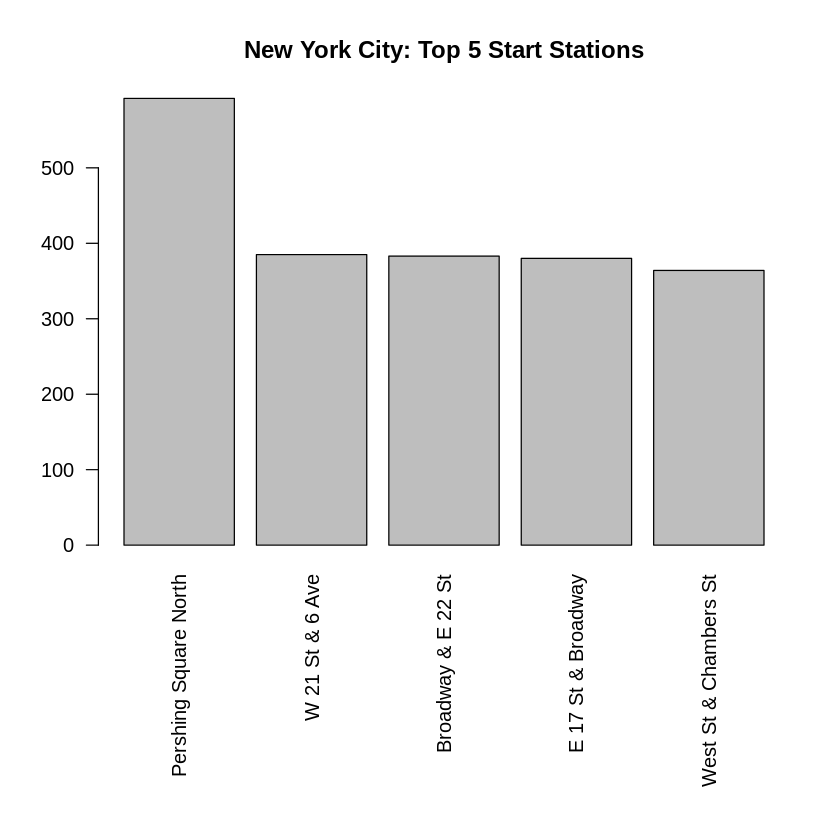

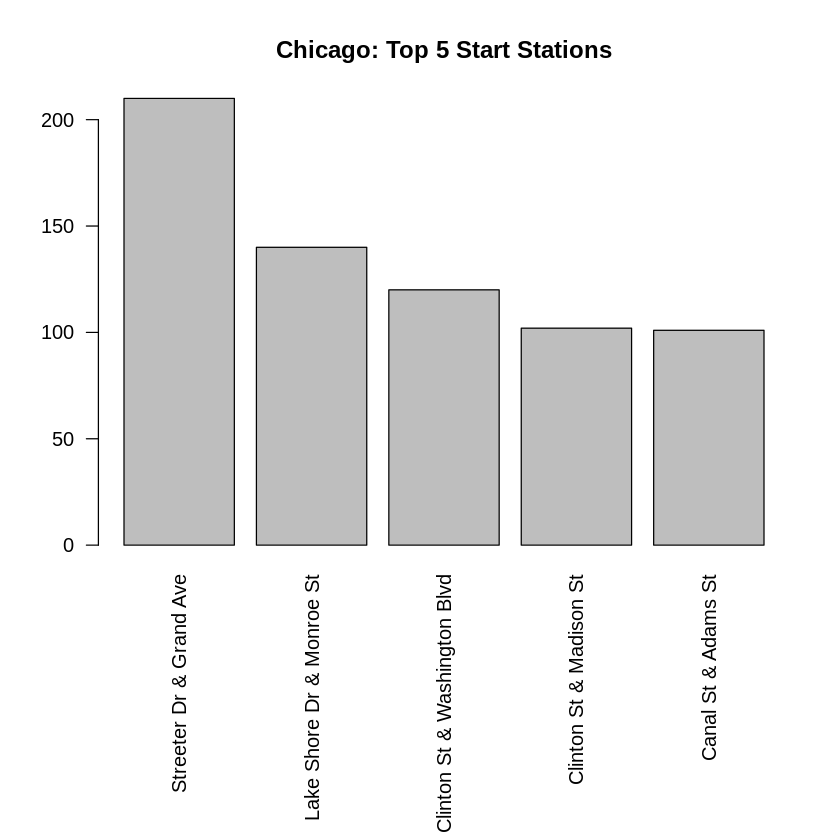

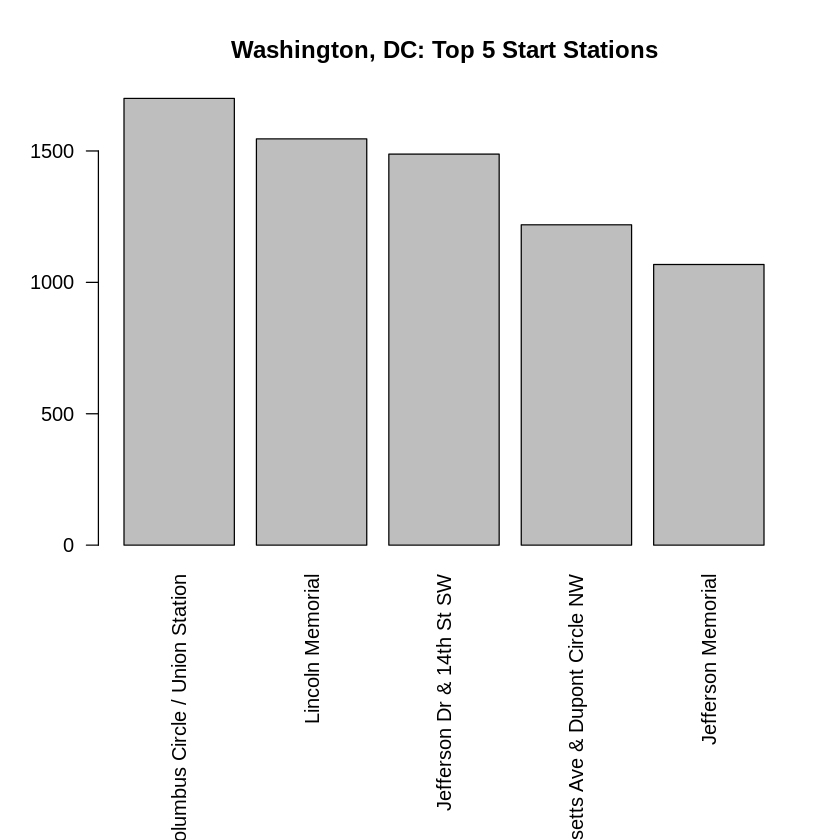

```r
# Plot: Top 5 start stations in New York City

# Adjust margins so long station names show correctly
par(mar = c(12, 4, 4, 2) + 0.1, mgp = c(5, 1, 0))

barplot(ny_station_df$trips,
        names.arg = ny_station_df$station,
        las = 2,
        main = "New York City: Top 5 Start Stations",
        xlab = "",
        ylab = "Number of Trips")

# Plot: Top 5 start stations in Chicago
barplot(chi_station_df$trips,
        names.arg = chi_station_df$station,
        las = 2,
        main = "Chicago: Top 5 Start Stations",
        xlab = "",
        ylab = "Number of Trips")

# Plot: Top 5 start stations in Washington, DC
barplot(wash_station_df$trips,
        names.arg = wash_station_df$station,
        las = 2,
        main = "Washington, DC: Top 5 Start Stations",
        xlab = "",
        ylab = "Number of Trips")

# Reset plotting parameters
par(mar = c(5, 4, 4, 2) + 0.1, mgp = c(3, 1, 0))
```

### Question 3

How does trip duration differ between cities?

```r
# Convert trip duration from seconds to minutes for each city
ny$trip_minutes   <- ny$Trip.Duration / 60
chi$trip_minutes  <- chi$Trip.Duration / 60
wash$trip_minutes <- wash$Trip.Duration / 60

head(ny$trip_minutes)
head(chi$trip_minutes)
head(wash$trip_minutes)
```

1. 13.25

2. 11.5333333333333

3. 22.0833333333333

4. 11.7166666666667

5. 5.48333333333333

6. 16.6333333333333

1. 5.35

2. 26.8333333333333

3. 6.93333333333333

4. 5.83333333333333

5. 8.9

6. 9.76666666666667

1. 8.1511

2. 6.70915

3. 10.62085

4. 30.4556833333333

5. 25.8237833333333

6. 6.63333333333333

```r
# Calculate mean and median trip duration (in minutes) for each city
ny_mean_duration   <- mean(ny$trip_minutes, na.rm = TRUE)
ny_median_duration <- median(ny$trip_minutes, na.rm = TRUE)

chi_mean_duration   <- mean(chi$trip_minutes, na.rm = TRUE)
chi_median_duration <- median(chi$trip_minutes, na.rm = TRUE)

wash_mean_duration   <- mean(wash$trip_minutes, na.rm = TRUE)
wash_median_duration <- median(wash$trip_minutes, na.rm = TRUE)

ny_mean_duration
ny_median_duration

chi_mean_duration
chi_median_duration

wash_mean_duration
wash_median_duration
```

15.0602448465373

10.1666666666667

15.6195461568173

11.1666666666667

20.5658889515254

11.7831833333333

```r
# Combine trip duration data for boxplot
trip_duration_data <- list(
  "New York City" = ny$trip_minutes,
  "Chicago" = chi$trip_minutes,
  "Washington, DC" = wash$trip_minutes
)
```

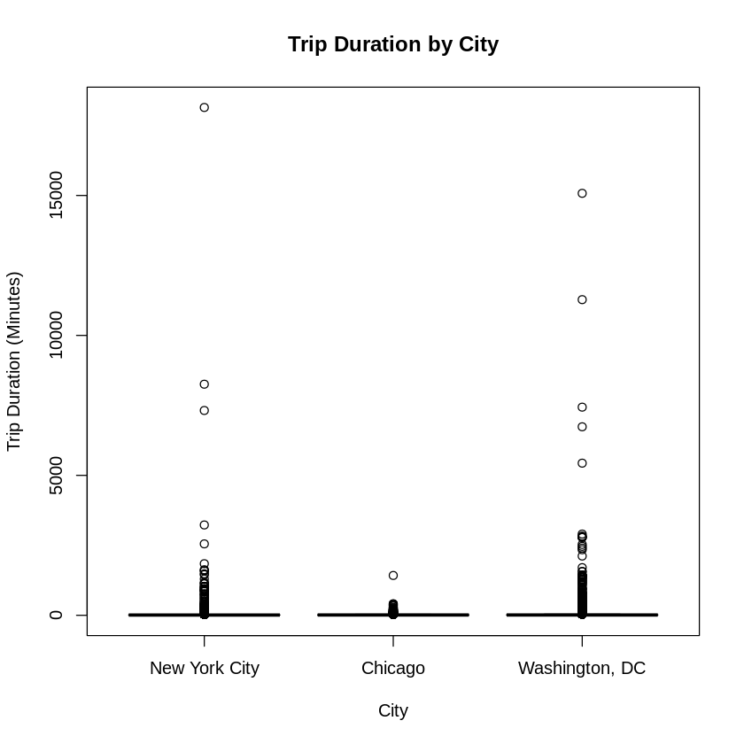

```r
# Boxplot: Trip duration by city (in minutes)
boxplot(trip_duration_data,
        main = "Trip Duration by City",
        xlab = "City",
        ylab = "Trip Duration (Minutes)")
```

**Summary of your question 3 results goes here.** Trip duration varies across cities, with Washington, DC having longer trips on average than New York City and Chicago. While the median trip durations are relatively similar across all three cities, the mean trip duration is notably higher in Washington, indicating a greater number of longer trips. In all cities, the mean exceeds the median, suggesting right-skewed trip duration distributions driven by a smaller number of long rides.

## Finishing Up

> Congratulations! You have reached the end of the Explore Bikeshare Data Project. You should be very proud of all you have accomplished!

> **Tip**: Once you are satisfied with your work here, check over your report to make sure that it is satisfies all the areas of the [rubric](https://review.udacity.com/#!/rubrics/2508/view).

## Directions to Submit

> Before you submit your project, you need to create a .html or .pdf version of this notebook in the workspace here. To do that, run the code cell below. If it worked correctly, you should get a return code of 0, and you should see the generated .html file in the workspace directory (click on the orange Jupyter icon in the upper left).

> Alternatively, you can download this report as .html via the **File** > **Download as** submenu, and then manually upload it into the workspace directory by clicking on the orange Jupyter icon in the upper left, then using the Upload button.

> Once you've done this, you can submit your project by clicking on the "Submit Project" button in the lower right here. This will create and submit a zip file with this .ipynb doc and the .html or .pdf version you created. Congratulations!

```r
system('python -m nbconvert Explore_bikeshare_data.ipynb')
```